# iDEP: Investigating Differentially Expressed Genes

## If this site has contributed to your work, please cite our article:

Ge, S.X., Son, E.W. & Yao, R. iDEP: an integrated web application for differential expression and pathway analysis of RNA-Seq data. BMC Bioinformatics 19, 534 (2018). https://doi.org/10.1186/s12859-018-2486-6

## Summary

Read Counts data were analyzed using iDEP v2.4.4. The data was first filtered to remove reads below 0.5 CPM in at least 1 sample. Then the data was transformed with EdgeR using a pseudocount of 4. Missing values were imputed using geneMedian.

After mapping, there are 32833 unique genes in 158 samples. Of the 24127 genes passed filter, 24127 were converted to Ensembl/STRING gene IDs in our database. The remaining 0 genes were kept in the data using original IDs.

Differential expression analysis was performed using DESeq2 with an FDR cutoff of 0.1 and a minimum fold-change threshold of 2. Standard Wald test was used and independent filtering was enabled.

## Selected Comparison: Time_After_Treatment_min720-Time_After_Treatment_min0

Up-regulated genes: 434

Down-regulated genes: 577

## Top Up-regulated Genes

```r
if (!is.null(params$up_genes_table) && nrow(params$up_genes_table) > 0) {
  kbl(params$up_genes_table, escape = FALSE) %>%
    kable_classic(full_width = FALSE, html_font = "Cambria")
} else {
  print("No up-regulated genes found for this comparison.")
}
```

| Symbol | Ensembl ID | log2 FC | Adj. P-value | Description |
| --- | --- | --- | --- | --- |
| AT2G09785 | AT2G09785 | 16.837 | 3.52e-04 | NcRNA |
| AT1G04163 | AT1G04163 | 14.116 | 1.84e-03 | NcRNA |
| AT1G05767 | AT1G05767 | 11.676 | 3.11e-08 | S-adenosyl-L-methionine-dependent methyltransferases superfamily protein |
| AT1G07500 | AT1G07500 | 9.620 | 1.07e-06 | Uncharacterized protein |
| AT3G51070 | AT3G51070 | 4.925 | 2.10e-02 | S-adenosyl-L-methionine-dependent methyltransferases superfamily protein |
| PAP14 | AT2G46880 | 4.149 | 6.21e-02 | Purple acid phosphatase 14 |
| AT4G06870 | AT4G06870 | 4.092 | 9.18e-02 | NcRNA |
| BHLH100 | AT2G41240 | 3.955 | 1.40e-04 | Basic helix-loop-helix protein 100 |
| atp9 | ATMG01080 | 3.755 | 7.29e-02 |  |
| AT5G03350 | AT5G03350 | 3.729 | 5.05e-05 | Legume lectin family protein |
| AT1G13608 | AT1G13608 | 3.526 | 1.58e-02 | Defensin-like (DEFL) family protein |
| ANK | AT5G54610 | 3.445 | 7.42e-03 | Ankyrin |
| AT5G15500 | AT5G15500 | 3.345 | 1.65e-02 | Ankyrin repeat family protein |
| PCC1 | AT3G22231 | 3.311 | 1.60e-02 | Pathogen and circadian controlled 1 |
| AT4G14819 | AT4G14819 | 3.194 | 6.38e-03 |  |
| WRKY62 | AT5G01900 | 3.151 | 7.42e-02 | WRKY DNA-binding protein 62 |
| bHLH38 | AT3G56970 | 3.147 | 1.77e-04 | Basic helix-loop-helix (bHLH) DNA-binding superfamily protein |
| BGL2 | AT3G57260 | 3.078 | 1.90e-02 | Beta-1,3-glucanase 2 |
| AT3G22235 | AT3G22235 | 3.032 | 8.63e-04 | Cysteine-rich TM module stress tolerance protein |
| AT5G40800 | AT5G40800 | 3.030 | 6.95e-04 | Uncharacterized protein |
| AT1G07367 | AT1G07367 | 3.005 | 2.36e-03 | NcRNA |
| WSD1 | AT5G37300 | 2.830 | 1.58e-03 | O-acyltransferase (WSD1-like) family protein |
| LURP1 | AT2G14560 | 2.803 | 4.26e-02 | LURP-one-like protein (DUF567) |
| CRK37 | AT4G04500 | 2.772 | 6.32e-02 | Cysteine-rich RLK (RECEPTOR-like protein kinase) 37 |
| AT5G44440 | AT5G44440 | 2.739 | 4.92e-02 | FAD-binding Berberine family protein |
| AT2G14247 | AT2G14247 | 2.729 | 1.58e-03 | Uncharacterized protein |
| AT1G13609 | AT1G13609 | 2.685 | 8.23e-03 | Defensin-like (DEFL) family protein |
| FT | AT1G65480 | 2.602 | 3.78e-04 | PEBP (phosphatidylethanolamine-binding protein) family protein |
| HB21 AT2G18550 | AT2G18550 | 2.602 | 2.10e-02 | Homeobox protein 21 |
| AT3G27250 | AT3G27250 | 2.598 | 4.06e-03 | Uncharacterized protein |
| ATMG01280 | ATMG01280 | 2.597 | 1.08e-02 |  |
| PCR1 | AT1G14880 | 2.595 | 8.89e-02 | PLANT CADMIUM RESISTANCE 1 |
| AT1G12030 | AT1G12030 | 2.528 | 1.07e-02 | Phosphoenolpyruvate carboxylase, putative (DUF506) |
| SAG29 | AT5G13170 | 2.527 | 5.41e-03 | Senescence-associated 29 |
| AT2G30300 | AT2G30300 | 2.524 | 4.75e-02 | Major facilitator superfamily protein |
| WRKY38 | AT5G22570 | 2.507 | 2.60e-02 | WRKY DNA-binding protein 38 |
| AT3G05845 | AT3G05845 | 2.489 | 5.38e-02 | NcRNA |
| AT3G08070 | AT3G08070 | 2.473 | 3.56e-02 | NcRNA |
| AT5G24200 | AT5G24200 | 2.436 | 4.12e-03 | Alpha/beta-Hydrolases superfamily protein |
| AT2G07629 | AT2G07629 | 2.430 | 1.92e-02 | Uncharacterized protein |
| AT5G10760 | AT5G10760 | 2.416 | 2.45e-02 | Eukaryotic aspartyl protease family protein |
| AT1G24580 | AT1G24580 | 2.408 | 4.41e-03 | RING/U-box superfamily protein |
| AT1G23110 | AT1G23110 | 2.406 | 1.25e-02 | Fold protein |
| AT1G23160 | AT1G23160 | 2.400 | 3.40e-02 | Auxin-responsive GH3 family protein |
| AT1G22680 | AT1G22680 | 2.389 | 7.18e-03 | Uncharacterized protein |
| AT1G70270 | AT1G70270 | 2.367 | 2.01e-03 | Transcription factor |
| AT1G62420 | AT1G62420 | 2.329 | 5.78e-02 | DUF506 family protein (DUF506) |
| bHLH39 | AT3G56980 | 2.327 | 8.77e-04 | Basic helix-loop-helix (bHLH) DNA-binding superfamily protein |
| AT2G08660 | AT2G08660 | 2.281 | 8.09e-02 | NcRNA |
| RK1 | AT1G65790 | 2.272 | 8.20e-02 | Receptor kinase 1 |

## Top Down-regulated Genes

```r
if (!is.null(params$down_genes_table) && nrow(params$down_genes_table) > 0) {
  kbl(params$down_genes_table, escape = FALSE) %>%
    kable_classic(full_width = FALSE, html_font = "Cambria")
} else {
  print("No down-regulated genes found for this comparison.")
}
```

| Symbol | Ensembl ID | log2 FC | Adj. P-value | Description |
| --- | --- | --- | --- | --- |
| AT1G55335 | AT1G55335 | -24.001 | 8.92e-04 | Uncharacterized protein |
| AT5G01645 | AT5G01645 | -15.658 | 2.31e-09 | NcRNA |
| TPS04 | AT1G61120 | -13.472 | 1.21e-11 | Terpene synthase 04 |
| PRA1.F4 | AT3G13710 | -12.319 | 5.09e-02 | Prenylated RAB acceptor 1.F4 |
| GMD1 | AT5G66280 | -11.517 | 1.07e-11 | GDP-D-mannose 4,6-dehydratase 1 |
| ATCG01000 | ATCG01000 | -10.597 | 1.83e-02 |  |
| AT1G09053 | AT1G09053 | -7.558 | 8.65e-03 | NcRNA |
| SESA3 | AT4G27160 | -6.304 | 7.04e-02 | Seed storage albumin 3 |
| AT1G33760 | AT1G33760 | -6.071 | 1.96e-04 | Integrase-type DNA-binding superfamily protein |
| AT1G15330 | AT1G15330 | -5.712 | 8.61e-05 | Cystathionine beta-synthase (CBS) protein |
| AT5G51190 | AT5G51190 | -5.562 | 3.72e-04 | Integrase-type DNA-binding superfamily protein |
| AT2G38240 | AT2G38240 | -5.558 | 2.19e-03 | 2-oxoglutarate (2OG) and Fe(II)-dependent oxygenase superfamily protein |
| AT1G18010 | AT1G18010 | -4.771 | 7.29e-02 | Major facilitator superfamily protein |
| PAP85 | AT3G22640 | -4.624 | 1.29e-02 | Cupin family protein |
| CYP81G1 | AT5G67310 | -4.452 | 6.75e-03 | Cytochrome P450, family 81, subfamily G, polypeptide 1 |
| RRTF1 | AT4G34410 | -4.435 | 1.28e-02 | Redox responsive transcription factor 1 |
| AT2G42560 | AT2G42560 | -4.394 | 3.87e-02 | Late embryosis abundant domain-containing protein / LEA domain-containing protein |
| AT5G07165 | AT5G07165 | -4.335 | 3.76e-02 | Uncharacterized protein |
| AT3G09870 | AT3G09870 | -4.262 | 4.96e-03 | SAUR-like auxin-responsive protein family |
| AT1G04560 | AT1G04560 | -4.237 | 8.29e-02 | AWPM-19-like family protein |
| LEA | AT2G21490 | -4.142 | 4.46e-02 | Dehydrin LEA |
| AT2G28490 | AT2G28490 | -4.076 | 4.15e-02 | RmlC-like cupins superfamily protein |
| AT3G21320 | AT3G21320 | -4.062 | 7.88e-03 | EARLY FLOWERING protein |
| OLEO1 | AT4G25140 | -4.057 | 7.06e-02 | Oleosin 1 |
| AT5G45475 | AT5G45475 | -4.048 | 5.82e-02 | NcRNA |
| DIN11 | AT3G49620 | -3.971 | 4.34e-06 | 2-oxoglutarate (2OG) and Fe(II)-dependent oxygenase superfamily protein |
| AT2G09665 | AT2G09665 | -3.948 | 5.48e-02 | NcRNA |
| AT3G15450 | AT3G15450 | -3.914 | 2.09e-05 | Aluminum induced protein with YGL and LRDR motifs |
| AT5G51585 | AT5G51585 | -3.887 | 6.14e-03 | Uncharacterized protein |
| PP2-B13 | AT1G56240 | -3.834 | 7.41e-04 | Phloem protein 2-B13 |
| SEN1 AT4G35770 | AT4G35770 | -3.782 | 5.02e-04 | Rhodanese/Cell cycle control phosphatase superfamily protein |
| ELI3-2 | AT4G37990 | -3.761 | 5.66e-02 | Cinnamyl alcohol dehydrogenase 8 |
| HSP17.4 | AT3G46230 | -3.729 | 5.46e-03 | Heat shock protein 17.4 |
| ZAT7 | AT3G46090 | -3.713 | 1.38e-04 | C2H2 and C2HC zinc fingers superfamily protein |
| BCB | AT5G20230 | -3.626 | 1.98e-06 | Blue-copper-binding protein |
| FLP1 | AT4G31380 | -3.602 | 1.99e-02 | Flowering-promoting factor-like protein |
| AT3G56920 | AT3G56920 | -3.556 | 4.80e-02 | DHHC-type zinc finger family protein |
| TPS13 | AT4G13300 | -3.519 | 9.83e-03 | Terpenoid synthase 13 |
| AT1G15125 | AT1G15125 | -3.450 | 9.91e-06 | S-adenosyl-L-methionine-dependent methyltransferases superfamily protein |
| AT3G23550 | AT3G23550 | -3.406 | 2.19e-05 | MATE efflux family protein |
| HSP17.6II | AT5G12020 | -3.406 | 1.30e-02 | 17.6 kDa class II heat shock protein |
| GSTF3 | AT2G02930 | -3.388 | 2.09e-03 | Glutathione S-transferase F3 |
| GAT1_2.1 | AT1G15040 | -3.375 | 9.81e-04 | Class I glutamine amidotransferase-like superfamily protein |
| JAZ7 | AT2G34600 | -3.353 | 4.49e-03 | Jasmonate-zim-domain protein 7 |
| OPT2 | AT1G09930 | -3.288 | 9.10e-03 | Oligopeptide transporter 2 |
| MIOX4 | AT4G26260 | -3.286 | 1.76e-03 | Myo-inositol oxygenase 4 |
| BCAT-2 | AT1G10070 | -3.283 | 3.58e-04 | Branched-chain amino acid transaminase 2 |
| AT5G05300 | AT5G05300 | -3.270 | 1.70e-02 | Uncharacterized protein |
| AACT1 AT5G61160 | AT5G61160 | -3.270 | 1.12e-03 | Anthocyanin 5-aromatic acyltransferase 1 |
| WRKY40 | AT1G80840 | -3.266 | 1.95e-04 | WRKY DNA-binding protein 40 |

## DEG Heatmap

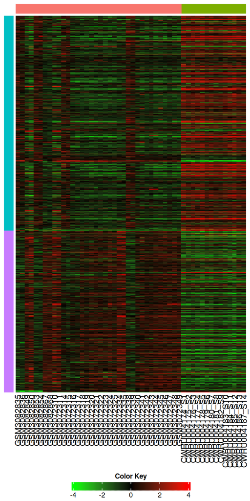

```r
if (!is.null(params$heat_data) && !is.null(params$heat_bar)) {
  heat_colors <- unlist(strsplit(params$heatmap_color_select, "-"))

  deg_heatmap(
    df = params$heat_data,
    bar = params$heat_bar,
    heatmap_color_select = heat_colors,
    cluster_rows = FALSE
  )
}
```

## Volcano Plot

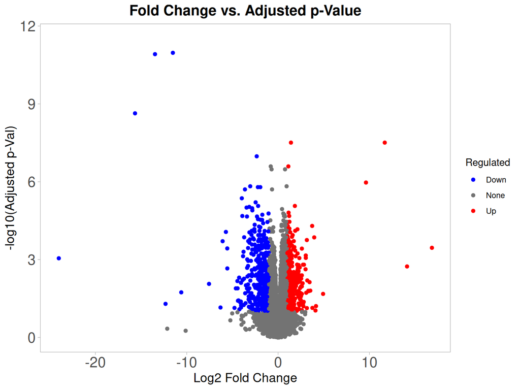

```r
if (!is.null(params$vol_data) && !is.null(params$vol_data$data)) {
  p <- plot_volcano(
    data = params$vol_data$data,
    plot_colors = params$plot_colors,
    anotate_genes = params$gene_labels_volcano
  )
  p <- refine_ggplot2(
    p = p,
    gridline = params$plot_grid_lines,
    ggplot2_theme = params$ggplot2_theme
  )
  print(p)
}
```